# chapter9 - Analysis of variances

alfonso

June 2, 2016

# 概要

方差分析所要解决的问题：

1. 农作物的产量，可能与作物品种有关，可能与施肥量有关，也可能与土壤有关
2. 化工产品的收率，可能与原料配方有关，可能与催化剂的用量有关，可能与反应温度有关等。

由于有很多因素，那么会有这样的问题：

1. 这些因素是不是都有显著的作用？
2. 如果不是，哪些因素显著？哪些因素不显著？
3. 这些因素的作用是简单叠加在一起，还是以更复杂的形式交错在一起？

单因子方差分析的假设前提：
某个指标的取值可能与一个因子 $A$ 有关，因子 $A$ 有 $r$ 个水平：$A_1,A_2,\ldots, A_r$，在这 $r$ 个水平下的指标值，可以看作是 $r$ 个相互独立、方差相等的正态总体。
$$\xi_i \sim N(\mu_i,\delta^2),\; i=1,2,\ldots,r$$

| 水平 | 观测值 |
| --- | --- |
| $A_1$ | $X_{11}, X_{12},\ldots,X_{1t}$ |
| $A_2$ | $X_{11}, X_{12},\ldots,X_{1t}$ |
| $\ldots$ | $\ldots$ |
| $A_r$ | $X_{11}, X_{12},\ldots,X_{1t}$ |

# 拟合模型

```r
library(dplyr)
library(multcomp)
df <- as_data_frame(cholesterol)
table(df$trt)
```

```
##
##  1time 2times 4times  drugD  drugE
##     10     10     10     10     10
```

```r
df %>%
  group_by(trt) %>%
  summarise(m = mean(response), sd = sd(response))
```

```
## Source: local data frame [5 x 3]
##
##      trt        m       sd
##   (fctr)    (dbl)    (dbl)
## 1  1time  5.78197 2.878113
## 2 2times  9.22497 3.483054
## 3 4times 12.37478 2.923119
## 4  drugD 15.36117 3.454636
## 5  drugE 20.94752 3.345003
```

```r
fit <- aov(response ~ trt, data = df)
summary(fit)
```

```
##             Df Sum Sq Mean Sq F value   Pr(>F)
## trt          4 1351.4   337.8   32.43 9.82e-13 ***
## Residuals   45  468.8    10.4
## ---
## Signif. codes:  0 '***' 0.001 '**' 0.01 '*' 0.05 '.' 0.1 ' ' 1
```

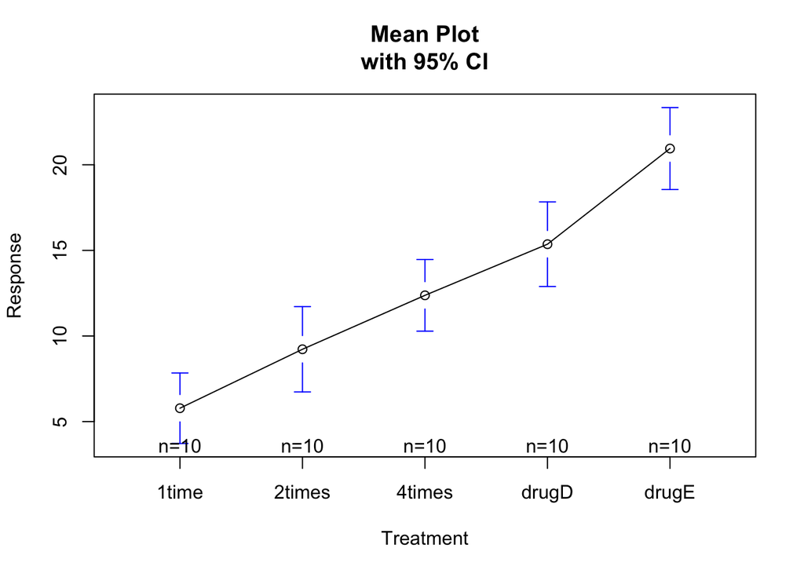

```r
library(gplots)
plotmeans(response ~ trt, data = df, xlab="Treatment", ylab="Response", main="Mean Plot\nwith 95% CI")
```

*confidence intervals short for CI*  
F 检验给出的结果表明，5种药的效果是不一样的。但没有告诉我们这5种药相互之间的不同。

```r
TukeyHSD(fit)
```

```
##   Tukey multiple comparisons of means
##     95% family-wise confidence level
##
## Fit: aov(formula = response ~ trt, data = df)
##
## $trt
##                   diff        lwr       upr     p adj
## 2times-1time   3.44300 -0.6582817  7.544282 0.1380949
## 4times-1time   6.59281  2.4915283 10.694092 0.0003542
## drugD-1time    9.57920  5.4779183 13.680482 0.0000003
## drugE-1time   15.16555 11.0642683 19.266832 0.0000000
## 4times-2times  3.14981 -0.9514717  7.251092 0.2050382
## drugD-2times   6.13620  2.0349183 10.237482 0.0009611
## drugE-2times  11.72255  7.6212683 15.823832 0.0000000
## drugD-4times   2.98639 -1.1148917  7.087672 0.2512446
## drugE-4times   8.57274  4.4714583 12.674022 0.0000037
## drugE-drugD    5.58635  1.4850683  9.687632 0.0030633
```

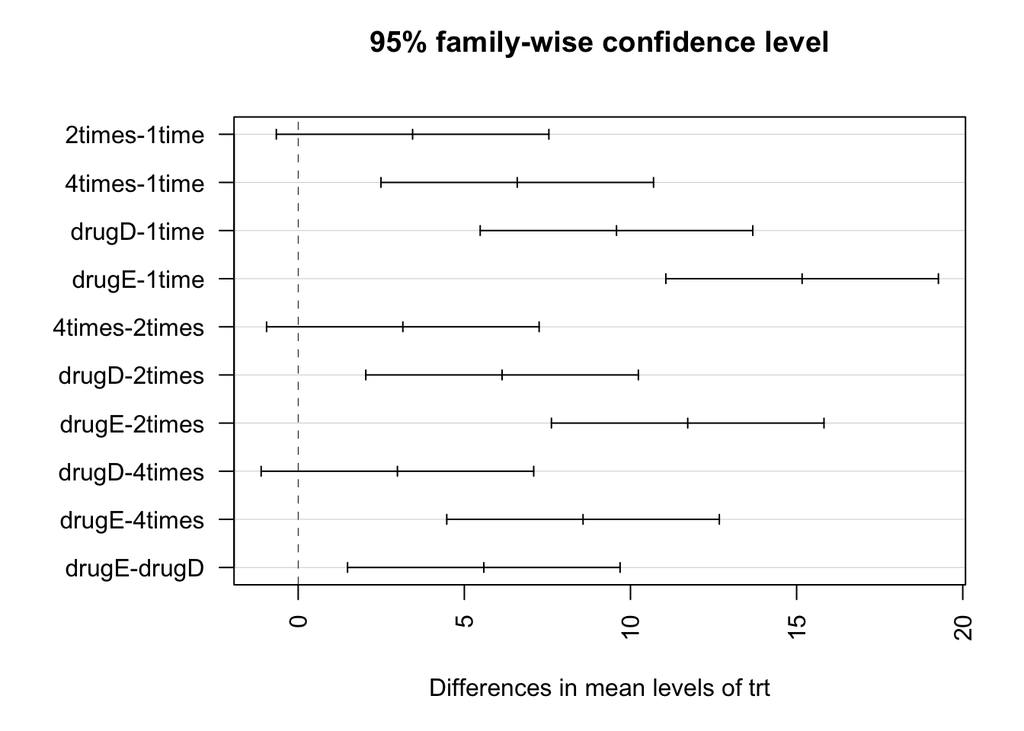

```r
par(las=2)
par(mar=c(5,8,4,2))
plot(TukeyHSD(fit))
```

从上可以看出，2times 和 1time 没有显著的区别（p = 0.138），而 4times 和 1time 差异很明显（p < 0.001）。上图种置信区间包含0的就说明没有显著的差异。

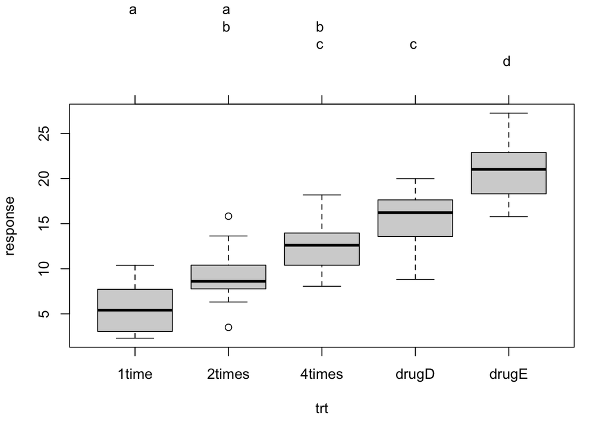

```r
library(multcomp)
par(mar=c(5,4,6,2))
tuk <- glht(fit, linfct=mcp(trt="Tukey"))
plot(cld(tuk, level=.05),col="lightgrey")
```

上图种标有相同字母的因素没有显著的差异。

我们对于结果的信心依赖于我们的数据满足统计检验下的假设。

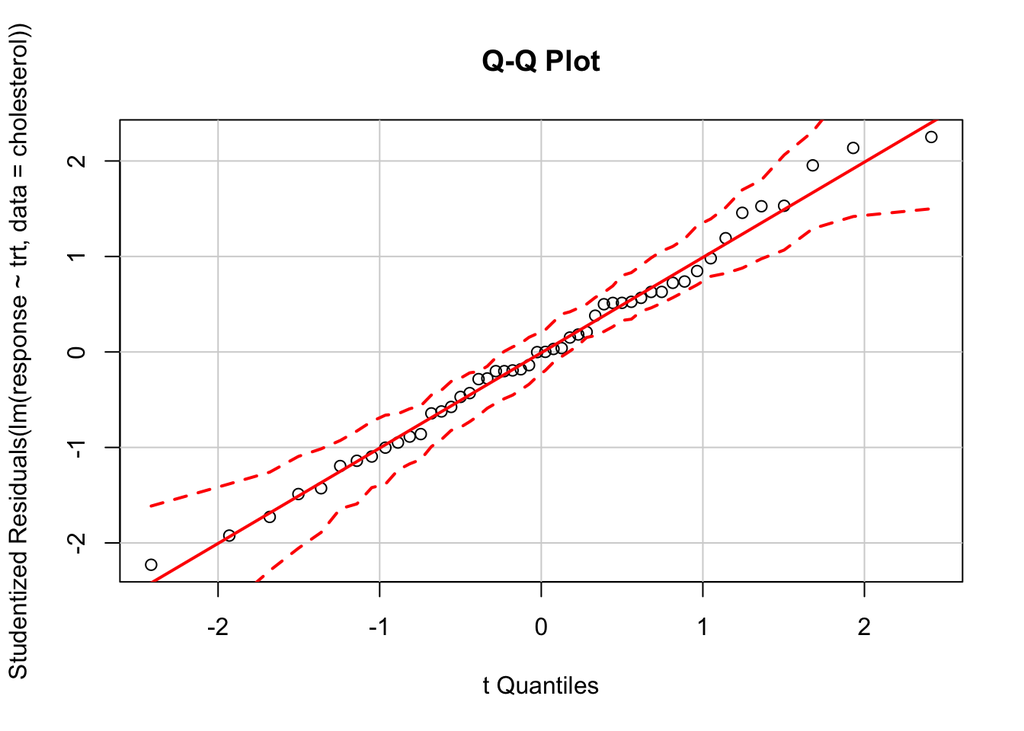

```r
library(car)
qqPlot(lm(response ~ trt, data=cholesterol),
                 simulate=TRUE, main="Q-Q Plot", labels=FALSE)
```

从上图可以看出，数据落在95%的置信区间内，所以我们的假设是合理的。

```r
bartlett.test(response ~ trt, data=cholesterol)
```

```
##
##  Bartlett test of homogeneity of variances
##
## data:  response by trt
## Bartlett's K-squared = 0.57975, df = 4, p-value = 0.9653
```

以上检验表明5组数据的方差没有显著的不同。  
最后方差分析对于异常值比较敏感，我们进行如下分析：

```r
outlierTest(fit)
```

```
##
## No Studentized residuals with Bonferonni p < 0.05
## Largest |rstudent|:
##    rstudent unadjusted p-value Bonferonni p
## 19 2.251149           0.029422           NA
```

结果表明没有异常值。

综上结合，qq 图，bartlett 检验，异常值检测，显示数据很符合方差分析的模型。